# Concurrent validity of an Estimator of Weekly Alcohol Consumption (EWAC) based on the Extended AUDIT

# 1 Background

The Alcohol Use Disorders Identification Test (AUDIT) [1] is a 10-item questionnaire schedule widely employed in clinical practice and clinical research as a diagnostic test for alcohol use disorder (ICD-10 F10.1/F10.2; ICD-11 QE10/6C40.1). Diagnostic studies show good predictive capabilities for both:

- clinical diagnoses (e.g. Composite International Diagnostic Interview, Structured Clinical Interview, Alcohol Use Disorder and Associated Disabilities Interview), and
- consumption in excess of maximum recommended intakes (e.g. 140g/week in Australia, 112 g/week in UK)

in a variety of clinical and community dwelling populations [2]. A variant of the AUDIT known as the ‘Extended AUDIT’ improves the granularity of the information collected on alcohol consumption. It follows the same schedule as the AUDIT, but provides a greater range of response options in the quantity and frequency items (questions 1 and 2). The Extended AUDIT has been used in UK research as part of two trials [3] and the Alcohol Toolkit Study [5] to capture greater information on the higher risk drinkers, based on the observation that consumption items are right-truncated.

The aim of the present study is develop an algorithm producing an Estimator of usual Weekly Alcohol Consumption in units (EWAC) using Extended AUDIT data as an input.

## 1.1 Literature on accuracy

A fundamental hindrance at the core of alcohol research and care is the absence of a measurement gold standard. A number of instruments exist which have been subjected to concurrent validity analysis instead. A review by [7] clarified how the various constructs have been operationalised through the Quantity-Frequency (QF) measures, Graduated-Frequency (GF) measures and prospective weekly diaries (WD). Broadly, WD tend to capture the highest alcohol consumption levels, followed by GF and the lowest levels are recorded by QF measures [8]. A large investigation conducted as part of the Health Survey for England (HSE) [10] compared a WD with an interview-based specific-beverage QF method. The authors found consistent mean weekly drinking estimates in the two methods, with most differences being associated with drink type and venue.

GF Hilton ME: A comparison of a prospective diary and two summary recall techniques for recording alcohol consumption. Br J Addict 84: 1085- 1092, 1989

Boniface S, Kneale J, Shelton N. Drinking pattern is more strongly associated with under-reporting of alcohol consumption than socio-demographic factors: evidence from a mixed-methods study. BMC Public Health [Internet] 2014;14(1):1297. PMID:25519144

Boniface S, Fuller E. Drinking diary. In: Craig R, Mindell J, editors. Heal Surv Engl 2011 Vol 1 Heal Soc care lifestyles [Internet] Health and Social Care Information Centre; 2012. Available from: http://content.digital.nhs.uk/catalogue/PUB09300

# 2 Methods

- estimating coefficients
- aggregate consistency between 2 sources
- missing data

# 3 Results

## 3.1 Empirical distribution functions

[output not shown]

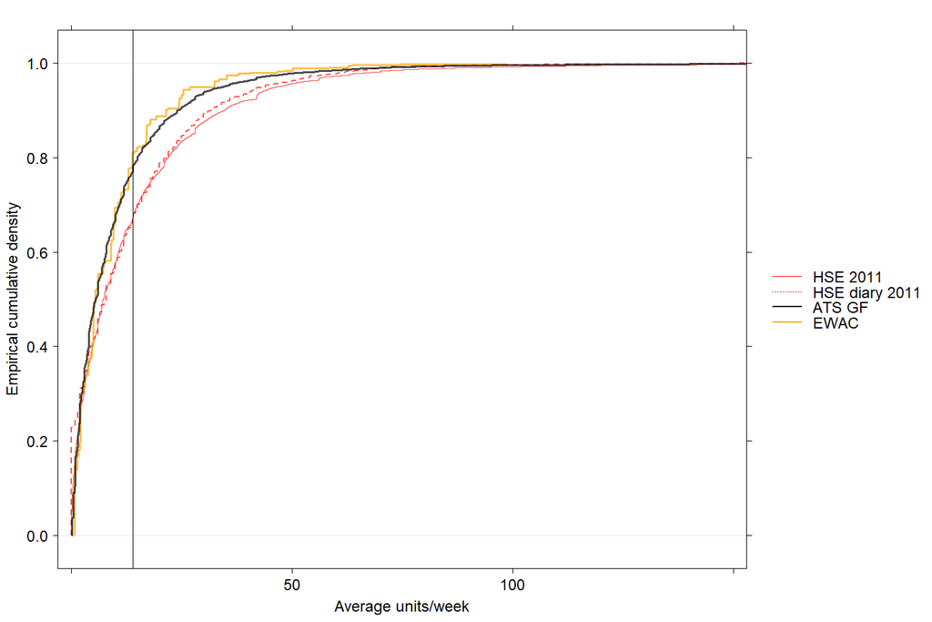

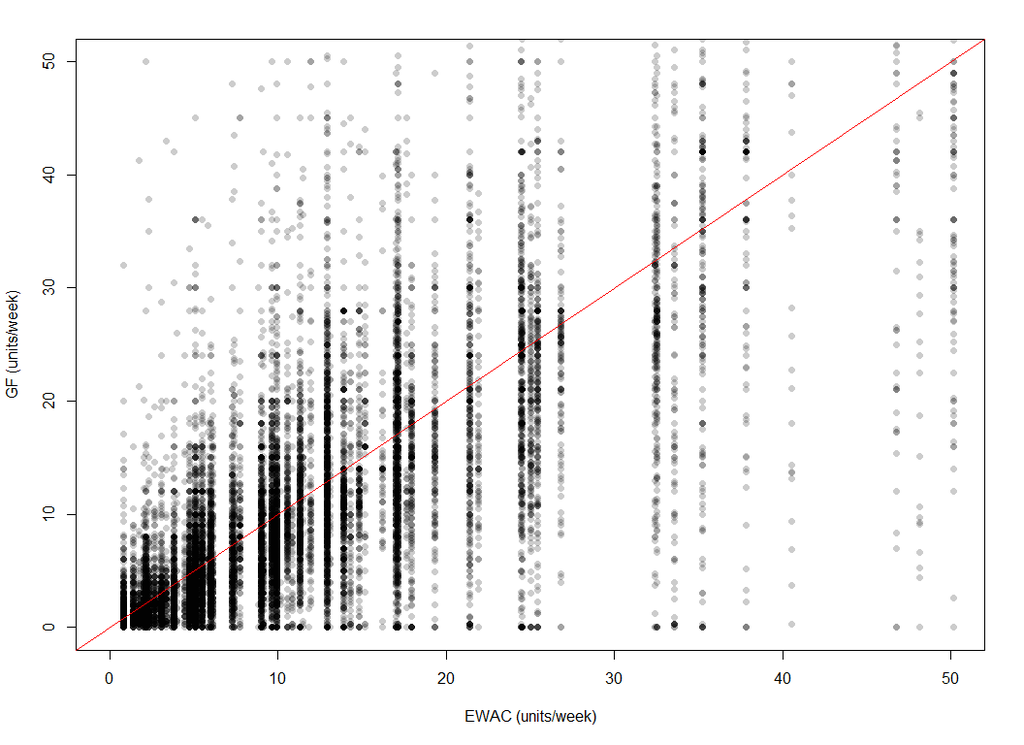

## 3.2 Regression analysis

[output not shown]

[output cut: 72 more lines]

[output not shown]

|  | Estimate | Std. Error | t value | Pr(>\|t\|) |
| --- | --- | --- | --- | --- |
| (Intercept) | -0.7213754 | 1.2961201 | -0.5565652 | 0.5778371 |
| as_factor(ageg)[25,35) | -1.1624896 | 0.5364100 | -2.1671661 | 0.0302459 |
| as_factor(ageg)[35,45) | -2.1142986 | 0.5381734 | -3.9286569 | 0.0000860 |
| as_factor(ageg)[45,55) | -1.2874290 | 0.5049784 | -2.5494733 | 0.0108035 |
| as_factor(ageg)[55,65) | -0.1021120 | 0.5139402 | -0.1986846 | 0.8425135 |
| as_factor(ageg)[65,75) | 1.1046547 | 0.5508426 | 2.0053907 | 0.0449484 |
| as_factor(ageg)[75,85) | 2.5042172 | 0.8309822 | 3.0135628 | 0.0025885 |
| as_factor(ageg)[85,105) | 3.4626613 | 1.8507613 | 1.8709389 | 0.0613829 |
| sexMen | -1.7062501 | 0.3610248 | -4.7261300 | 0.0000023 |
| sexIn another way | 9.3504803 | 8.4872528 | 1.1017087 | 0.2706150 |
| favdrinkCider | -2.1649427 | 0.7070304 | -3.0620222 | 0.0022044 |
| favdrinkMixed spirits | 0.5833844 | 0.6789849 | 0.8592008 | 0.3902505 |
| favdrinkOther | 3.2444044 | 1.7427519 | 1.8616559 | 0.0626811 |
| favdrinkSpirits alone | 0.4913529 | 0.5889195 | 0.8343295 | 0.4041154 |
| favdrinkWine | 0.7875438 | 0.3823538 | 2.0597254 | 0.0394508 |
| alcoriskIncreased | 2.5154383 | 1.2236164 | 2.0557409 | 0.0398336 |
| alcoriskHigher | 0.8540673 | 1.2564459 | 0.6797486 | 0.4966795 |

|  | Estimate | Std. Error | t value | Pr(>\|t\|) |
| --- | --- | --- | --- | --- |
| (Intercept) | 41.223824 | 180.88374 | 0.2279023 | 0.8197269 |
| as_factor(ageg)[25,35) | 31.690568 | 74.86023 | 0.4233298 | 0.6720638 |
| as_factor(ageg)[35,45) | 288.519319 | 75.10633 | 3.8414781 | 0.0001231 |
| as_factor(ageg)[45,55) | 81.667404 | 70.47371 | 1.1588351 | 0.2465513 |
| as_factor(ageg)[55,65) | 132.739190 | 71.72440 | 1.8506840 | 0.0642447 |
| as_factor(ageg)[65,75) | 101.059704 | 76.87442 | 1.3146077 | 0.1886722 |
| as_factor(ageg)[75,85) | 59.802755 | 115.97010 | 0.5156739 | 0.6060937 |
| as_factor(ageg)[85,105) | 561.202460 | 258.28829 | 2.1727755 | 0.0298208 |
| sexMen | 7.922007 | 50.38385 | 0.1572331 | 0.8750644 |
| sexIn another way | 43.616067 | 1184.46284 | 0.0368235 | 0.9706265 |
| favdrinkCider | 177.286113 | 98.67164 | 1.7967281 | 0.0724092 |
| favdrinkMixed spirits | -80.330755 | 94.75768 | -0.8477492 | 0.3965981 |
| favdrinkOther | -112.216132 | 243.21473 | -0.4613871 | 0.6445310 |
| favdrinkSpirits alone | 47.272525 | 82.18835 | 0.5751730 | 0.5651873 |
| favdrinkWine | -64.846915 | 53.36048 | -1.2152611 | 0.2242954 |
| alcoriskIncreased | 19.505609 | 170.76529 | 0.1142247 | 0.9090620 |
| alcoriskHigher | 348.938405 | 175.34690 | 1.9899890 | 0.0466195 |

# 4 Discussion

- GF not missing at random. Impute the 14.8% missing cases

# 5 Limitations

The three sources of information used in this validation measure different constructs: the HSE quantity-frequency does not capture variability, whereas the HSE weekly diary and the ATS graduated frequency schedule do. The HSE diary should nevertheless exhibit smaller recall error.

The AUDIT-E used is administred using a CAPI. These findings are not easily transferable to self-administered AUDITs. Mention the difference between CAPI and self admin AUDIT in previous literature. Higher or lower?

# 6 Tables

Table 1: Overview of alcohol schedule used in this paper.

Survey module

Schedule

- On how many days, if any, did you personally drink a drink containing alcohol in the last four weeks?
- What was the maximum number of units you personally consumed on any one day when drinking an alcoholic drink or drinks in the last four weeks?
- On how many days, if any, in the last four weeks did you personally drink… [prompting in turn ‘51-60 units?’, ‘41-50 units?’, …, '1-2 units?

*Health Survey for England*

- Thinking now about all kinds of drinks, how often have you had an alcoholic drink of any kind during the last 12 months? *[8 items from ‘Almost every day’ to ‘Not at all in the last 12 months’]*
- Did you have an alcoholic drink in the seven days ending yesterday?
- On how many days out of the last seven did you have an alcoholic drink?
- Which day last week did you last have an alcoholic drink/have the most to drink?
- Thinking about last [answer to previous question], what types of drink did you have that day? [list of 8 types of alcohol beverages]
- [running through each type of beverage and recording number of units drunk]

# 7 References

[1] Babor TF, Higgins-Biddle JC, Saunders JB, Monteiro MG. The Alcohol Use Disorders Identification Test. Guidelines for Use in Primary Care. Second Edition. Geneva: World Health Organisation, Department of Mental Health; Substance Dependence; 2001.

[2] Meneses-Gaya C de, Zuardi AW, Loureiro SR, Crippa JAS. Alcohol Use Disorders Identification Test (AUDIT): An updated systematic review of psychometric properties. Psychology & Neuroscience 2009;2:83–97. doi:10.3922/j.psns.2009.1.12.

[3] Kaner E, Bland M, Cassidy P, Coulton S, Dale V, Deluca P, et al. Effectiveness of screening and brief alcohol intervention in primary care (SIPS trial): pragmatic cluster randomised controlled trial. BMJ 2013;346:e8501–1. doi:10.1136/bmj.e8501.

[4] Crane D, Garnett C, Michie S, West R, Brown J. A smartphone app to reduce excessive alcohol consumption: Identifying the effectiveness of intervention components in a factorial randomised control trial. Scientific Reports 2018;8:4384. doi:10.1038/s41598-018-22420-8.

[5] Beard E, Brown J, West R, Acton C, Brennan A, Drummond C, et al. Protocol for a national monthly survey of alcohol use in England with 6-month follow-up: ’The Alcohol Toolkit Study’ Health behavior, health promotion and society. BMC Public Health 2015;15. doi:10.1186/s12889-015-1542-7.

[6] Lemmens P, Tan ES, Knibbe R a. Measuring quantity and frequency of drinking in a general population survey: a comparison of five indices. Journal of Studies on Alcohol 1992;53:476–86. doi:10.15288/jsa.1992.53.476.

[7] Greenfield TK. Ways of measuring drinking patterns and the difference they make: experience with graduated frequencies. Journal of Substance Abuse 2000;12:33–49. doi:10.1016/S0899-3289(00)00039-0.

[8] Heeb J-L, Gmel G. Measuring alcohol consumption: A comparison of graduated frequency, quantity frequency, and weekly recall diary methods in a general population survey. Addictive Behaviors 2005;30:403–13. doi:10.1016/j.addbeh.2004.04.022.

[9] Rehm J. Measuring Quantity, Frequency, and Volume of Drinking. Alcoholism: Clinical and Experimental Research 1998;22:4s–14s. doi:10.1111/j.1530-0277.1998.tb04368.x.

[10] Boniface S, Kneale J, Shelton N. Drinking pattern is more strongly associated with under-reporting of alcohol consumption than socio-demographic factors: evidence from a mixed-methods study. BMC Public Health 2014;14:1297. doi:10.1186/1471-2458-14-1297.

[11] Stockwell T, Donath S, Cooper-Stanbury M, Chikritzhs T, Catalano P, Mateo C. Under-reporting of alcohol consumption in household surveys: A comparison of quantity-frequency, graduated-frequency and recent recall. Addiction 2004;99:1024–33. doi:10.1111/j.1360-0443.2004.00815.x.

[12] Stockwell T, Zhao J, Macdonald S. Who under-reports their alcohol consumption in telephone surveys and by how much? An application of the ’yesterday method’ in a national Canadian substance use survey. Addiction (Abingdon, England) 2014;109:1657–66. doi:10.1111/add.12609.

[13] Feunekes GIJ, van ’t Veer P, Staveren Wa van, Kok FJ. Alcohol Intake Assessment: The Sober Facts. American Journal of Epidemiology 1999;150:105–12. doi:10.1093/oxfordjournals.aje.a009909.